# Simple Linear Regression: Model Comparison

2025

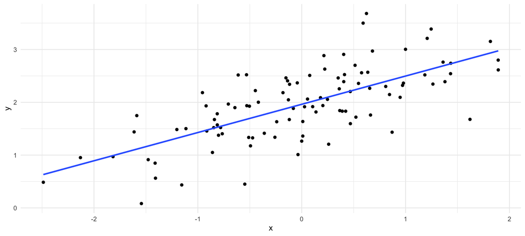

## Simple linear regression in `R`

```
##
## Call:
## lm(formula = y ~ x, data = d)
##
## Residuals:
##      Min       1Q   Median       3Q      Max
## -1.21922 -0.31921 -0.01861  0.31228  1.38601
##
## Coefficients:
##             Estimate Std. Error t value Pr(>|t|)
## (Intercept)  1.96237    0.04995  39.284  < 2e-16 ***
## x            0.53481    0.05515   9.698 5.48e-16 ***
## ---
## Signif. codes:  0 '***' 0.001 '**' 0.01 '*' 0.05 '.' 0.1 ' ' 1
##
## Residual standard error: 0.4995 on 98 degrees of freedom
## Multiple R-squared:  0.4897, Adjusted R-squared:  0.4845
## F-statistic: 94.05 on 1 and 98 DF,  p-value: 5.478e-16
```

## Regression as model comparison

- \(SS_{error} = SS_{residual} = \sum_{i=1}^{n} (y_{i} - \hat{y_{i}})^2\)
  - \(SS_{error}\) is what you get when you compare raw observations against the full model predictions.
- \(SS_{total} = \sum_{i=1}^{n} (y_{i} - \bar{y_{i}})^2\)
  - \(SS_{total}\) is what you get when you compare raw observations against the grand mean.

## Regression as model comparison

- \(SS_{error}\) comes from \(\sum_{i=1}^{n} (y_{i} - \hat{y_{i}})^2\) with \(\hat{y} = \beta_{0} + \beta_{1} x + \epsilon\),
- \(SS_{total}\) comes from \(\sum_{i=1}^{n} (y_{i} - \hat{y_{i}})^2\) with \(\hat{y} = \bar{y} + \epsilon\)
- \(SS_{model} = \sum_{i=1}^{n} (\bar{y} - \hat{y_i})^2\) tells you how much the added complexity of the full model reduces the overall variability (i.e., makes better predictions).

## Regression as model comparison

- The percent of variability accounted for above the simple model is given by:

\[R^2 = \frac{SS_{model}}{SS_{total}}\]

- \(R^2\) is called the **coefficient of determination** and is just the sqaure of the correlation coefficient between \(x\) and \(y\).

## Regression as model comparison

- The regression \(F\)-test compares two models:
  - A **simple model** that only predicts the mean of \(Y\)
  - A **full model** that predicts \(Y\) using \(X\)
- The \(F\)-statistic tells us whether the full model provides a significantly better fit.

\[ F = \frac{MS_{\text{model}}}{MS_{\text{error}}} \sim F(df_1, df_2) \]

- Intuition: How much better is the model with \(X\), compared to just using the mean, relative to how noisy the data are?

## Regression vs correlation

- Both are used to examine the relationship between variables.
- The sign of the regression coefficient (positive or negative) in simple linear regression involving one independent variable will always match the sign of the correlation coefficient between those two variables.
- In simple linear regression with one predictor, the square of the correlation coefficient \(r^2\) is equal to the coefficient of determination in regression analysis.
- Correlation provides a single metric describing the linear relationship between two variables.
- Regression is used to model the relationship and predict values, offering more detailed insight into how the variables interact.

## Regression vs correlation

- In simple linear regression, \(R^2\) (which is a measure of how well the variation in the dependent variable is explained by the independent variables) is exactly the square of the correlation coefficient \(r\)).

\[ R^2 = \frac{SS_{model}}{SS_{total}} = r^2 \]